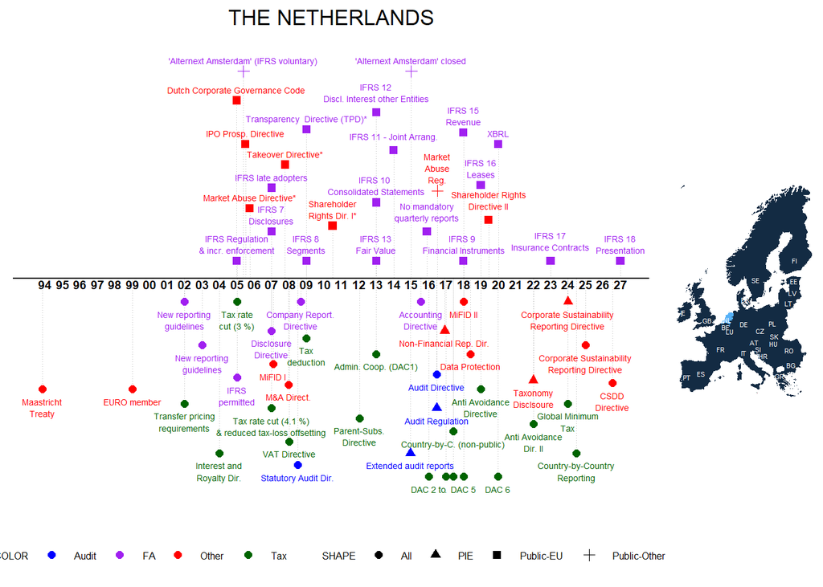

Notes: The graph depicts major regulatory changes that we identified via an extensive literature search, an online survey of mentioned authors, and other sources. Please note that the graph does not include all possible regulatory changes, e.g. minor revisions to local GAAP or tax rate changes below 3% are not included. The dates of EU Directives are based on the official transposition deadlines unless denoted with a *, in which case we included the entry-to-force date as identified in the literature. For more information, please go to [Labro and Pierk (2023)](http://www.eu-regulations.com/Labro_Pierk_2023.pdf). We kindly ask that you cite the paper if you use the information on this website in your research project. Do you have comments or see anything missing? Please email us!

## Regulations, Publications, Further Graphs

The tab ‘Regulations’ includes links to the regulations, gives short descriptions, and provides selective papers for further reading. If the regulation is a national transposition of an EU Directive, the link to the Directive is given. The tab ‘Number of Regulations’ shows graphically the number of regulations 8 years around the respective year (-4,-3,-2,-1,0,+1,+2,+3). The tab ‘Number of Categories” shows graphically the number of different categories 8 years around the respective year (-4,-3,-2,-1,0,+1,+2,+3). The tab ’Publications’ shows all publications that include the countries’ names and variations thereof in the title, abstract, or keywords. Similarly, the tab ‘SSRN’ shows papers of the SSRN Accouning Research Network that include the countries’ names and variations.

### Regulations

[output not shown]

[output cut: 55 more lines]

### Number of Regulations

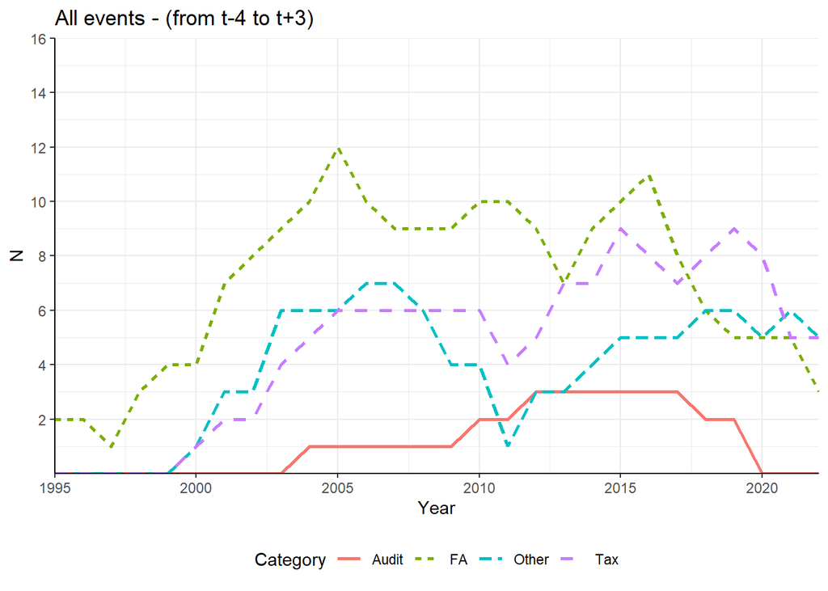

### Number of Categories

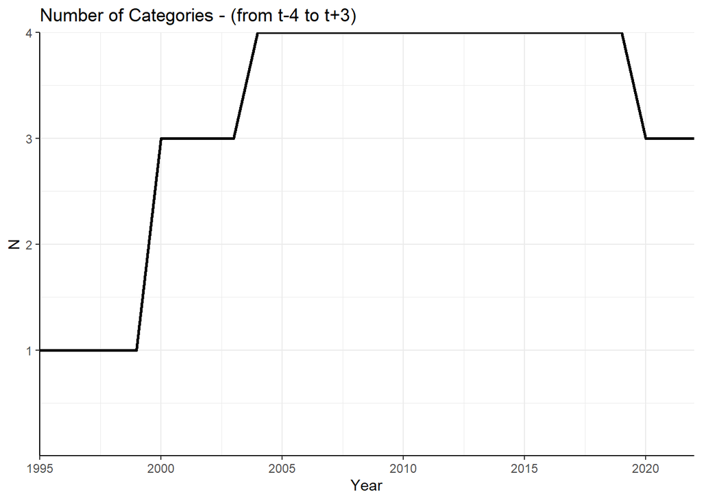

### Publications

|  | authors | title | year | journal |
| --- | --- | --- | --- | --- |
| 1 | Detzen D., De Vries M., Wong A. | young professionals and the institute: giving a voice to the next generation of accountants? | 2021 | European Accounting Review |
| 2 | Vergoossen R.G.A., van Beest F. | management reports of dutch companies: their availability and compliance with legal disclosure requirements | 2021 | Accounting in Europe |
| 3 | Woudenberg J., van der Hel–van Dijk L., Kamerling R. | auditor’s reporting in the dutch market of public interest entities: exploring new developments in a diverse market | 2021 | Accounting in Europe |
| 4 | Clune C., O'Dwyer B. | organizing dissonance through institutional work: the embedding of social and environmental accountability in an investment field | 2020 | Accounting, Organizations and Society |
| 5 | Clune C., O’Dwyer B. | framing engagement that resonates: organizing advocacy for corporate social and environmental accountability | 2020 | European Accounting Review |
| 6 | Çakmaklı A.D., Boone C., van Witteloostuijn A. | identity realization, multiple logics and legitimacy: organizational foundings during the emergence of the dutch accounting industry | 2020 | Accounting, Organizations and Society |
| 7 | Boomsma R., O'Dwyer B. | constituting the governable ngo: the correlation between conduct and counter-conduct in the evolution of funder-ngo accountability relations | 2019 | Accounting, Organizations and Society |
| 8 | Troshani I., Janssen M., Lymer A., Parker L.D. | digital transformation of business-to-government reporting: an institutional work perspective | 2018 | International Journal of Accounting Information Systems |
| 9 | Van Duin S.R., Dekker H.C., Wielhouwer J.L., Mendoza J.P. | the tone from above: the effect of communicating a supportive regulatory strategy on reporting quality | 2018 | Journal of Accounting Research |
| 10 | Brouwer A., Hoogendoorn M. | the role and current status of ifrs in the completion of national accounting rules–evidence from the netherlands | 2017 | Accounting in Europe |

[output cut: 72 more lines]

### SSRN

|  | authors | title | Posted | Revised |
| --- | --- | --- | --- | --- |
| 1 | Shivaram Rajgopal | has european corporatism delivered? a survey with preliminary evidence | 2021-09-21 |  |
| 2 | Peter Kroos, Mario Schabus and Frank Verbeeten | the relation between internal forecasting sophistication and accounting misreporting | 2021-09-02 |  |
| 3 | Dennis De Widt, Iolo Llewelyn and Tim Thorogood | liberalising audit markets for local government: the five forces at work in england and the netherlands | 2021-08-09 |  |
| 4 | Manuel Lokin and Jeroen Veldman | the potential of the dutch corporate governance model for sustainable governance and long term stakeholder value | 2021-07-29 |  |
| 5 | Olga N. Volkova | the impact of corporate social responsibility on the corporate financial performance: evidence from russian and dutch companies | 2021-06-10 |  |
| 6 | Utz Weitzel and Michael Kirchler | the banker's oath and financial advice | 2021-02-18 | 2021-08-09 |
| 7 | Sanne Janssen, Kris Hardies, Ann Vanstraelen and Karla M. Zehms | professional skepticism traits and fraud brainstorming quality | 2020-12-29 |  |
| 8 | David S. Bedford, Roland F. Spekle and Sally K. Widener | budgeting and employee stress in times of crisis: evidence from the covid-19 pandemic | 2020-12-25 |  |
| 9 | Michael P. Krzus | philip morris international integrated report 2019: analyzing the content | 2020-11-20 |  |
| 10 | Robin Litjens and Jeroen Suijs | can firms foresee the proprietary cost of mandatory public disclosure? | 2020-05-28 | 2020-07-09 |